# ¿Qué factores influyen en el precio de vehiculo?

Somos analistas de una empresa de anuncios. Cientos de anuncios gratuitos de vehículos se publican en el sitio web cada día. Necesitamos estudiar los datos recopilados durante los últimos años y determinar qué factores influyen en el precio de un vehículo.

# Tabla de contenidos

## Inicialización

```python
# Cargamos todas las librerías
import pandas as pd
from IPython.display import display, HTML
import matplotlib.pyplot as plt
import numpy as np
```

```python
def print_mejorado(texto,size):
    size=str(size)
    display(HTML('<span style="font-size: '+size+'px;">'+texto+'</span>'))
```

### Carga de datos

```python
# Cargamos el archivo de datos en un DataFrame
data=pd.read_csv('/datasets/vehicles_us.csv')
```

### Explorando datos iniciales

El dataset contiene los siguientes campos:

- `price`
- `model_year`
- `model`
- `condition`
- `cylinders`
- `fuel` — gasolina, diesel, etc.
- `odometer` — el millaje del vehículo cuando el anuncio fue publicado
- `transmission`
- `paint_color`
- `is_4wd` — si el vehículo tiene tracción a las 4 ruedas (tipo Booleano)
- `date_posted` — la fecha en la que el anuncio fue publicado
- `days_listed` — desde la publicación hasta que se elimina

```python
#Información general/resumida sobre el DataFrame
data.info()
```

```
<class 'pandas.core.frame.DataFrame'>
RangeIndex: 51525 entries, 0 to 51524
Data columns (total 13 columns):
 #   Column        Non-Null Count  Dtype
---  ------        --------------  -----
 0   price         51525 non-null  int64
 1   model_year    47906 non-null  float64
 2   model         51525 non-null  object
 3   condition     51525 non-null  object
 4   cylinders     46265 non-null  float64
 5   fuel          51525 non-null  object
 6   odometer      43633 non-null  float64
 7   transmission  51525 non-null  object
 8   type          51525 non-null  object
 9   paint_color   42258 non-null  object
 10  is_4wd        25572 non-null  float64
 11  date_posted   51525 non-null  object
 12  days_listed   51525 non-null  int64
dtypes: float64(4), int64(2), object(7)
memory usage: 5.1+ MB
```

*Hay valores ausentes en `model_year`,`cylinders`,`odometer`,`paint_color`y un gran numero en `is_4wd`*

`cylinders` es un float, seria conveniente que sea un int, se corregira más adelante  
`is_4wd` es un float, seria conveniente que sea un int, se corregira más adelante  
`date_posted` es un object, deberia ser un datetime, se corregira más adelante

```python
# imprimimos una muestra de datos
data.head(5)
```

|  | price | model_year | model | condition | cylinders | fuel | odometer | transmission | type | paint_color | is_4wd | date_posted | days_listed |
| --- | --- | --- | --- | --- | --- | --- | --- | --- | --- | --- | --- | --- | --- |
| 0 | 9400 | 2011.0 | bmw x5 | good | 6.0 | gas | 145000.0 | automatic | SUV | NaN | 1.0 | 2018-06-23 | 19 |
| 1 | 25500 | NaN | ford f-150 | good | 6.0 | gas | 88705.0 | automatic | pickup | white | 1.0 | 2018-10-19 | 50 |
| 2 | 5500 | 2013.0 | hyundai sonata | like new | 4.0 | gas | 110000.0 | automatic | sedan | red | NaN | 2019-02-07 | 79 |
| 3 | 1500 | 2003.0 | ford f-150 | fair | 8.0 | gas | NaN | automatic | pickup | NaN | NaN | 2019-03-22 | 9 |
| 4 | 14900 | 2017.0 | chrysler 200 | excellent | 4.0 | gas | 80903.0 | automatic | sedan | black | NaN | 2019-04-02 | 28 |

```python
data['is_4wd'].value_counts()
```

```
1.0    25572
Name: is_4wd, dtype: int64
```

```python
data['paint_color'].value_counts()
```

```
white     10029
black      7692
silver     6244
grey       5037
blue       4475
red        4421
green      1396
brown      1223
custom     1153
yellow      255
orange      231
purple      102
Name: paint_color, dtype: int64
```

### Conclusiones y siguientes pasos

A primera vista, se puede apreciar que hay datos ausentes en `model year`, `odometer`, `cylinders`, `paint_color` y `is_4wd`. Ademas, hay columnas que tienen tipos de datos incorrectos.

## Tratando valores ausentes

*En la columna `cylinders` faltan 5260 filas(10.2% de los datos). Procederé a calcular las medianas de cylinders por modelo y a reemplazar según corresponda usando un función personalizada.*

```python
#pd.set_option('display.max_rows', None)
data.query('cylinders.notna()').pivot_table(index=('model'),values='cylinders',aggfunc=('mean','median'))
```

| model | mean | median |
| --- | --- | --- |
| acura tl | 5.971564 | 6.0 |
| bmw x5 | 6.406375 | 6.0 |
| buick enclave | 6.000000 | 6.0 |
| cadillac escalade | 7.986395 | 8.0 |
| chevrolet camaro | 6.887097 | 6.0 |
| ... | ... | ... |
| toyota sienna | 5.952381 | 6.0 |
| toyota tacoma | 5.345205 | 6.0 |
| toyota tundra | 7.919561 | 8.0 |
| volkswagen jetta | 4.281116 | 4.0 |
| volkswagen passat | 4.325949 | 4.0 |

100 rows × 2 columns

```python
def valores_ausentes_cyl(df):
    modelo=df['model']

    #creo un dataframe auxiliar con los valores medios de cilindrada por modelo
    df2=data.groupby(['model']).agg({'cylinders': ['median']})
    media =df2.loc[(modelo), ('cylinders','median')]
    return media

# Comprobación de la función
df_test = pd.DataFrame({'model': ['acura tl', 'bmw x5','acura tl']})
df_test['test']=df_test.apply(valores_ausentes_cyl, axis=1)
df_test
```

|  | model | test |
| --- | --- | --- |
| 0 | acura tl | 6.0 |
| 1 | bmw x5 | 6.0 |
| 2 | acura tl | 6.0 |

```python
valores_reemplazo = data.query('cylinders.isna()').apply(valores_ausentes_cyl, axis=1)
data['cylinders'] = data['cylinders'].fillna(valores_reemplazo)
```

*En la columna `paint_color` faltan algunas filas. No se puede inferir con exactitud de que color eran las filas faltantes, asi que estos datos ausentes seran remplazados como "unknown"(desconocido).*

```python
data['paint_color'].fillna('unknown', inplace=True)
data['paint_color'].value_counts()
```

```
white      10029
unknown     9267
black       7692
silver      6244
grey        5037
blue        4475
red         4421
green       1396
brown       1223
custom      1153
yellow       255
orange       231
purple       102
Name: paint_color, dtype: int64
```

*En la columna `is_4wd` vemos que todos los 25572 valores son 1(es 4x4). Es probable entonces que el valor de las finalas restantes sea 0 (no 4x4). Procederé a arreglar.*

```python
data['is_4wd'].fillna(0, inplace=True)
data['is_4wd'].value_counts()
```

```
0.0    25953
1.0    25572
Name: is_4wd, dtype: int64
```

```python
data.info()
```

```
<class 'pandas.core.frame.DataFrame'>
RangeIndex: 51525 entries, 0 to 51524
Data columns (total 13 columns):
 #   Column        Non-Null Count  Dtype
---  ------        --------------  -----
 0   price         51525 non-null  int64
 1   model_year    47906 non-null  float64
 2   model         51525 non-null  object
 3   condition     51525 non-null  object
 4   cylinders     51525 non-null  float64
 5   fuel          51525 non-null  object
 6   odometer      43633 non-null  float64
 7   transmission  51525 non-null  object
 8   type          51525 non-null  object
 9   paint_color   51525 non-null  object
 10  is_4wd        51525 non-null  float64
 11  date_posted   51525 non-null  object
 12  days_listed   51525 non-null  int64
dtypes: float64(4), int64(2), object(7)
memory usage: 5.1+ MB
```

*Finalmente, respecto a las columnas `model_year` y `odometer` faltan una cantidad significtiva de datos. No se puede suponer claramente que tipo de valor correponde a estos parametros, asi que de momento, dejaré estas columnas asi.*

## Corregir los tipos de datos

```python
data['date_posted'] = pd.to_datetime(data['date_posted'], format='%Y-%m-%d')
data['cylinders'] = data['cylinders'].astype('int64')
data['is_4wd'] = data['is_4wd'].astype('int64')
data.info()
```

```
<class 'pandas.core.frame.DataFrame'>
RangeIndex: 51525 entries, 0 to 51524
Data columns (total 13 columns):
 #   Column        Non-Null Count  Dtype
---  ------        --------------  -----
 0   price         51525 non-null  int64
 1   model_year    47906 non-null  float64
 2   model         51525 non-null  object
 3   condition     51525 non-null  object
 4   cylinders     51525 non-null  int64
 5   fuel          51525 non-null  object
 6   odometer      43633 non-null  float64
 7   transmission  51525 non-null  object
 8   type          51525 non-null  object
 9   paint_color   51525 non-null  object
 10  is_4wd        51525 non-null  int64
 11  date_posted   51525 non-null  datetime64[ns]
 12  days_listed   51525 non-null  int64
dtypes: datetime64[ns](1), float64(2), int64(4), object(6)
memory usage: 5.1+ MB
```

## Enriquecer datos

```python
# Agregamos valores de fecha y hora para cuando se colocó el anuncio

data['year_posted'] = data['date_posted'].dt.year
data['month_posted'] = data['date_posted'].dt.month
data['dayofweek_posted'] = data['date_posted'].dt.dayofweek

data.head(5)
```

|  | price | model_year | model | condition | cylinders | fuel | odometer | transmission | type | paint_color | is_4wd | date_posted | days_listed | year_posted | month_posted | dayofweek_posted |
| --- | --- | --- | --- | --- | --- | --- | --- | --- | --- | --- | --- | --- | --- | --- | --- | --- |
| 0 | 9400 | 2011.0 | bmw x5 | good | 6 | gas | 145000.0 | automatic | SUV | unknown | 1 | 2018-06-23 | 19 | 2018 | 6 | 5 |
| 1 | 25500 | NaN | ford f-150 | good | 6 | gas | 88705.0 | automatic | pickup | white | 1 | 2018-10-19 | 50 | 2018 | 10 | 4 |
| 2 | 5500 | 2013.0 | hyundai sonata | like new | 4 | gas | 110000.0 | automatic | sedan | red | 0 | 2019-02-07 | 79 | 2019 | 2 | 3 |
| 3 | 1500 | 2003.0 | ford f-150 | fair | 8 | gas | NaN | automatic | pickup | unknown | 0 | 2019-03-22 | 9 | 2019 | 3 | 4 |
| 4 | 14900 | 2017.0 | chrysler 200 | excellent | 4 | gas | 80903.0 | automatic | sedan | black | 0 | 2019-04-02 | 28 | 2019 | 4 | 1 |

```python
# Agregamos los años aproximados del vehículo cuando el anuncio se colocó
data['years_vehicle'] = data['year_posted']-data['model_year']
data.head(5)
```

|  | price | model_year | model | condition | cylinders | fuel | odometer | transmission | type | paint_color | is_4wd | date_posted | days_listed | year_posted | month_posted | dayofweek_posted | years_vehicle |
| --- | --- | --- | --- | --- | --- | --- | --- | --- | --- | --- | --- | --- | --- | --- | --- | --- | --- |
| 0 | 9400 | 2011.0 | bmw x5 | good | 6 | gas | 145000.0 | automatic | SUV | unknown | 1 | 2018-06-23 | 19 | 2018 | 6 | 5 | 7.0 |
| 1 | 25500 | NaN | ford f-150 | good | 6 | gas | 88705.0 | automatic | pickup | white | 1 | 2018-10-19 | 50 | 2018 | 10 | 4 | NaN |
| 2 | 5500 | 2013.0 | hyundai sonata | like new | 4 | gas | 110000.0 | automatic | sedan | red | 0 | 2019-02-07 | 79 | 2019 | 2 | 3 | 6.0 |
| 3 | 1500 | 2003.0 | ford f-150 | fair | 8 | gas | NaN | automatic | pickup | unknown | 0 | 2019-03-22 | 9 | 2019 | 3 | 4 | 16.0 |
| 4 | 14900 | 2017.0 | chrysler 200 | excellent | 4 | gas | 80903.0 | automatic | sedan | black | 0 | 2019-04-02 | 28 | 2019 | 4 | 1 | 2.0 |

```python
# Agregamos el millaje promedio del vehículo por año
#Si 'years_vehicle' es 0, entonces asigna NaN
data['mill_mean'] = np.where(data['years_vehicle'] == 0, np.nan, data['odometer'] / data['years_vehicle'])
data.head(5)
```

|  | price | model_year | model | condition | cylinders | fuel | odometer | transmission | type | paint_color | is_4wd | date_posted | days_listed | year_posted | month_posted | dayofweek_posted | years_vehicle | mill_mean |
| --- | --- | --- | --- | --- | --- | --- | --- | --- | --- | --- | --- | --- | --- | --- | --- | --- | --- | --- |
| 0 | 9400 | 2011.0 | bmw x5 | good | 6 | gas | 145000.0 | automatic | SUV | unknown | 1 | 2018-06-23 | 19 | 2018 | 6 | 5 | 7.0 | 20714.285714 |
| 1 | 25500 | NaN | ford f-150 | good | 6 | gas | 88705.0 | automatic | pickup | white | 1 | 2018-10-19 | 50 | 2018 | 10 | 4 | NaN | NaN |
| 2 | 5500 | 2013.0 | hyundai sonata | like new | 4 | gas | 110000.0 | automatic | sedan | red | 0 | 2019-02-07 | 79 | 2019 | 2 | 3 | 6.0 | 18333.333333 |
| 3 | 1500 | 2003.0 | ford f-150 | fair | 8 | gas | NaN | automatic | pickup | unknown | 0 | 2019-03-22 | 9 | 2019 | 3 | 4 | 16.0 | NaN |
| 4 | 14900 | 2017.0 | chrysler 200 | excellent | 4 | gas | 80903.0 | automatic | sedan | black | 0 | 2019-04-02 | 28 | 2019 | 4 | 1 | 2.0 | 40451.500000 |

```python
# Reemplazamos los valores de condición con algo que se pueda manipular más fácilmente
print(data['condition'].unique())
data['condition'].replace({"new": 5, "like new": 4, "excellent": 3, "good": 2, "fair": 1, "salvage": 0}, inplace=True)
print(data['condition'].unique())

#tranformamos la columna a un valor int64
data['condition'] = data['condition'].astype('int64')
```

```
['good' 'like new' 'fair' 'excellent' 'salvage' 'new']
[2 4 1 3 0 5]
```

## Comprobar datos limpios

```python
# imprime la información general/resumida sobre el DataFrame
data.info()
```

```
<class 'pandas.core.frame.DataFrame'>
RangeIndex: 51525 entries, 0 to 51524
Data columns (total 18 columns):
 #   Column            Non-Null Count  Dtype
---  ------            --------------  -----
 0   price             51525 non-null  int64
 1   model_year        47906 non-null  float64
 2   model             51525 non-null  object
 3   condition         51525 non-null  int64
 4   cylinders         51525 non-null  int64
 5   fuel              51525 non-null  object
 6   odometer          43633 non-null  float64
 7   transmission      51525 non-null  object
 8   type              51525 non-null  object
 9   paint_color       51525 non-null  object
 10  is_4wd            51525 non-null  int64
 11  date_posted       51525 non-null  datetime64[ns]
 12  days_listed       51525 non-null  int64
 13  year_posted       51525 non-null  int64
 14  month_posted      51525 non-null  int64
 15  dayofweek_posted  51525 non-null  int64
 16  years_vehicle     47906 non-null  float64
 17  mill_mean         38751 non-null  float64
dtypes: datetime64[ns](1), float64(4), int64(8), object(5)
memory usage: 7.1+ MB
```

```python
# imprimimos una muestra de datos
data.head(5)
```

|  | price | model_year | model | condition | cylinders | fuel | odometer | transmission | type | paint_color | is_4wd | date_posted | days_listed | year_posted | month_posted | dayofweek_posted | years_vehicle | mill_mean |
| --- | --- | --- | --- | --- | --- | --- | --- | --- | --- | --- | --- | --- | --- | --- | --- | --- | --- | --- |
| 0 | 9400 | 2011.0 | bmw x5 | 2 | 6 | gas | 145000.0 | automatic | SUV | unknown | 1 | 2018-06-23 | 19 | 2018 | 6 | 5 | 7.0 | 20714.285714 |
| 1 | 25500 | NaN | ford f-150 | 2 | 6 | gas | 88705.0 | automatic | pickup | white | 1 | 2018-10-19 | 50 | 2018 | 10 | 4 | NaN | NaN |
| 2 | 5500 | 2013.0 | hyundai sonata | 4 | 4 | gas | 110000.0 | automatic | sedan | red | 0 | 2019-02-07 | 79 | 2019 | 2 | 3 | 6.0 | 18333.333333 |
| 3 | 1500 | 2003.0 | ford f-150 | 1 | 8 | gas | NaN | automatic | pickup | unknown | 0 | 2019-03-22 | 9 | 2019 | 3 | 4 | 16.0 | NaN |
| 4 | 14900 | 2017.0 | chrysler 200 | 3 | 4 | gas | 80903.0 | automatic | sedan | black | 0 | 2019-04-02 | 28 | 2019 | 4 | 1 | 2.0 | 40451.500000 |

## Estudiamos parámetros principales

Los parámetros a estudiar seran:

- Precio
- Los años del vehículo cuando el anuncio se colocó
- Millaje
- Número de cilindros
- Estado

```python
#Creamos funcion para vizualizar rapidamente los histogramas y datos descriptivos de cada columna
def histo_des(col):
    fig, (ax1, ax2) = plt.subplots(nrows=1, ncols=2, figsize=(20, 8))
    data[col].hist(ax=ax1,bins=100, figsize=(20,5))
    ax1.set_xlabel('Valores')
    ax1.set_ylabel('Frecuencia')

    ax2.axis('off')
    ax2.text(0, 0.5, str(data[col].describe()), fontsize=20, va='center')
    plt.subplots_adjust(wspace=0.5)
    plt.show()
```

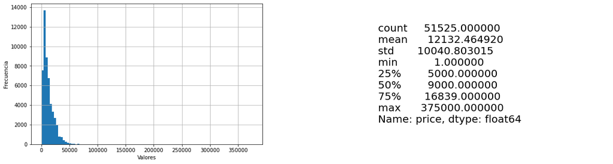

```python
#Analizamos los precios
histo_des('price')
```

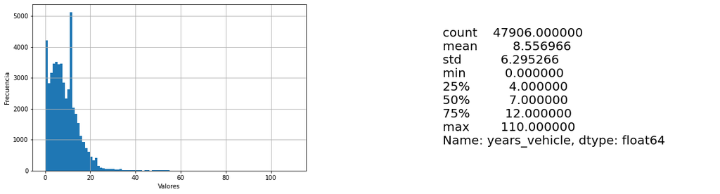

```python
#Analizamos los años del vehiculo
histo_des('years_vehicle')
```

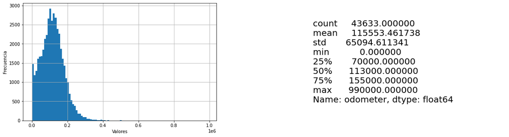

```python
#Analizamos las millas (odometro)
histo_des('odometer')
```

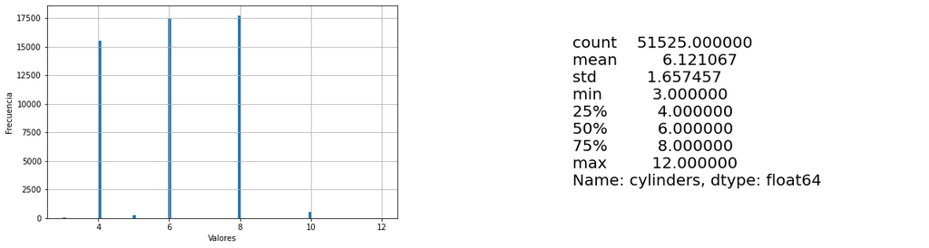

```python
#Analizamos el numero de cilindros
histo_des('cylinders')
```

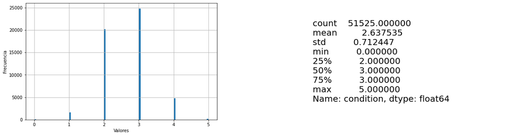

```python
#Analizamos el estado
histo_des('condition')
```

## Estudiamos y tratamos valores atípicos

A continuación cálcularemos los rangos tipicos usando las siguiente formula:  
Rango inferior= Q2 - 1.5*IQR  
Rango superior= Q 2 +1.5*IQR

Donde IQR = Q3-Q1 (Rango intercuartílico)  
Q1=Primer cuartil, es el valor tal que el 25% está por debajo de él  
Q2=Segundo cuartil, es el valor tal que el 50% cae por debajo y el 50% está por encima  
Q3=Tercer cuartil, es el valor tal que el 25% de los valores está por encima de él

Una vez obtenido el rango típico para cada columna, se procecerá a crear una nueva tabla eliminando los valores fuera de estos rangos (valores atípicos).

```python
# Funcion que determina los límites inferiores
def lim_inferior(df,col):
    Q1 = df[col].quantile(0.25)
    Q2 = df[col].quantile(0.5)
    Q3 = df[col].quantile(0.75)
    IQR=(Q3-Q1)
    return (Q2-1.5*IQR)

lim_inferior_price= lim_inferior(data,'price')
lim_inferior_years_vehicle= lim_inferior(data,'years_vehicle')
lim_inferior_odometer= lim_inferior(data,'odometer')

print(f'Limite inferior price: {lim_inferior_price}')
print(f'Limite inferior years_vehicle: {lim_inferior_years_vehicle}')
print(f'Limite inferior odometer: {lim_inferior_odometer}')
```

```
Limite inferior price: -8758.5
Limite inferior years_vehicle: -5.0
Limite inferior odometer: -14500.0
```

```python
# Funcion que determina los límites superiores
def lim_superior(df,col):
    Q1 = df[col].quantile(0.25)
    Q2 = df[col].quantile(0.5)
    Q3 = df[col].quantile(0.75)
    IQR=(Q3-Q1)
    return (Q2+1.5*IQR)

lim_superior_price= lim_superior(data,'price')
lim_superior_years_vehicle= lim_superior(data,'years_vehicle')
lim_superior_odometer= lim_superior(data,'odometer')

print(f'Limite superior price: {lim_superior_price}')
print(f'Limite superior years_vehicle: {lim_superior_years_vehicle}')
print(f'Limite superior odometer: {lim_superior_odometer}')
```

```
Limite superior price: 26758.5
Limite superior years_vehicle: 19.0
Limite superior odometer: 240500.0
```

```python
# Almacena los datos sin valores atípicos en un DataFrame separado (data2)
data2=data.query('(@lim_inferior_price < price < @lim_superior_price) and (@lim_inferior_years_vehicle < years_vehicle < @lim_superior_years_vehicle) and (@lim_inferior_odometer < odometer < @lim_superior_odometer)')
data2.info()
```

```
<class 'pandas.core.frame.DataFrame'>
Int64Index: 33889 entries, 0 to 51523
Data columns (total 18 columns):
 #   Column            Non-Null Count  Dtype
---  ------            --------------  -----
 0   price             33889 non-null  int64
 1   model_year        33889 non-null  float64
 2   model             33889 non-null  object
 3   condition         33889 non-null  int64
 4   cylinders         33889 non-null  int64
 5   fuel              33889 non-null  object
 6   odometer          33889 non-null  float64
 7   transmission      33889 non-null  object
 8   type              33889 non-null  object
 9   paint_color       33889 non-null  object
 10  is_4wd            33889 non-null  int64
 11  date_posted       33889 non-null  datetime64[ns]
 12  days_listed       33889 non-null  int64
 13  year_posted       33889 non-null  int64
 14  month_posted      33889 non-null  int64
 15  dayofweek_posted  33889 non-null  int64
 16  years_vehicle     33889 non-null  float64
 17  mill_mean         32856 non-null  float64
dtypes: datetime64[ns](1), float64(4), int64(8), object(5)
memory usage: 4.9+ MB
```

## Estudiamos parámetros principales sin valores atípicos

Comparamos los histogramas de nuestra tabla sin datos atipicos (data2) con la tabla original (data)

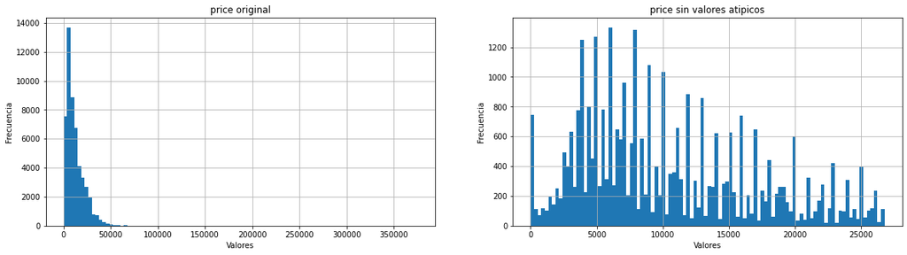

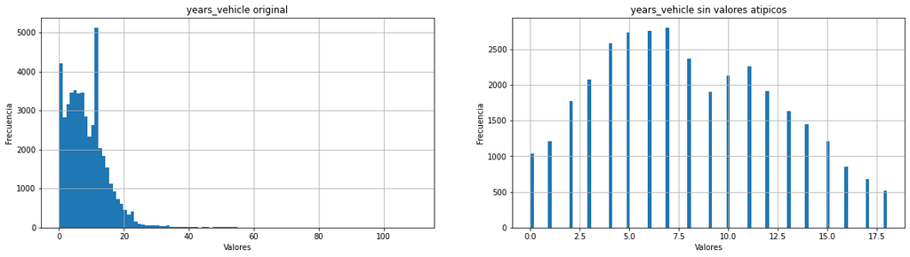

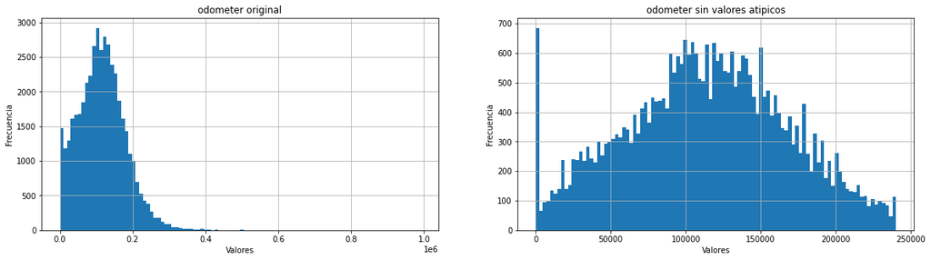

```python
def comp_histogramas(col):
    fig, (ax1, ax2) = plt.subplots(nrows=1, ncols=2, figsize=(20, 8))

    data[col].hist(ax=ax1,bins=100, figsize=(20,5))
    ax1.set_xlabel('Valores')
    ax1.set_ylabel('Frecuencia')
    ax1.set_title(f'{col} original')

    data2[col].hist(ax=ax2,bins=100, figsize=(20,5))
    ax2.set_xlabel('Valores')
    ax2.set_ylabel('Frecuencia')
    ax2.set_title(f'{col} sin valores atipicos')


comp_histogramas('price')
comp_histogramas('years_vehicle')
comp_histogramas('odometer')
```

## Periodo de colocación de los anuncios

Estudiamos cuántos días los anuncios fueron mostrados (`days_listed`). Calculamos la media y la mediana. Describimos el periodo de colocación habitual de un anuncio. Determinamos cuándo se eliminaron rápidamente los anuncios y cuándo son publicados por un tiempo anormalmente largo.

Media de colocación de anuncios: 39.66 días

Mediana de colocación de anuncios: 33.00 días

Los anuncios que duraron extremadamente poco fueron de 0 días

Los anuncios que duraron demasiado fueron de: 84.0 dias

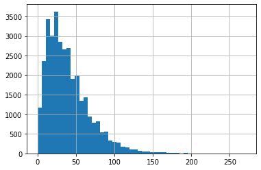

```python
data2['days_listed'].hist(bins=50)
mean=data2['days_listed'].mean()
median=data2['days_listed'].median()
#print(f'<span style="font-size: 24px;">Media de colocación de anuncios: {mean}</span>')
print_mejorado(f'Media de colocación de anuncios: {mean:.2f} días',24)
print_mejorado(f'Mediana de colocación de anuncios: {median:.2f} días',24)

lim_superior_listed= lim_superior(data,'days_listed')

#display(HTML('<span style="font-size: 24px;">Hola Mundo</span>'))

print_mejorado(f'Los anuncios que duraron extremadamente poco fueron de 0 días',24)
print_mejorado(f'Los anuncios que duraron demasiado fueron de: {lim_superior_listed} dias',24)
```

## Precio promedio por cada tipo de vehículo

**Analizamos el número de anuncios y el precio promedio para cada tipo de vehículo. Trazamos un gráfico mostrando la dependencia de la cantidad de anuncios para los modelos de vehiculos con mas de 300 anuncios**

| model | anuncios | precio_promedio |
| --- | --- | --- |
| ford f-150 | 1749.0 | 12501.130360 |
| chevrolet silverado 1500 | 1355.0 | 13567.106273 |
| ram 1500 | 1178.0 | 13674.985569 |
| toyota camry | 731.0 | 7374.891929 |
| chevrolet silverado | 727.0 | 12812.949106 |
| ... | ... | ... |
| ford f350 super duty | 136.0 | 13884.786765 |
| chevrolet silverado 3500hd | 113.0 | 17814.141593 |
| ford f350 | 113.0 | 16068.371681 |
| ford f-250 super duty | 95.0 | 12848.421053 |
| chevrolet silverado 1500 crew | 91.0 | 24478.571429 |

99 rows × 2 columns

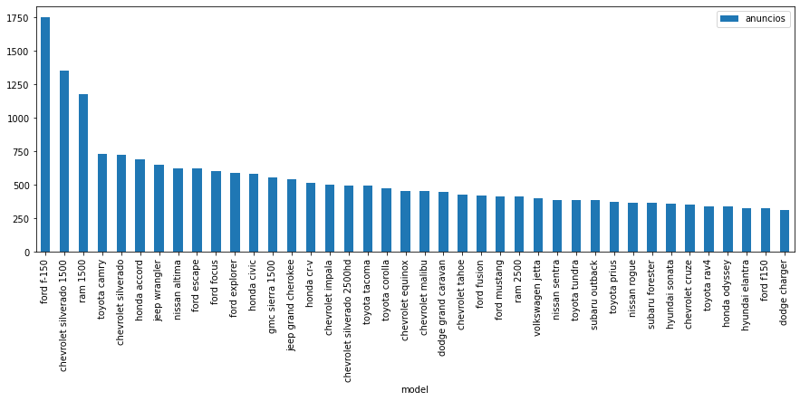

```python
anuncios_precios=data2.pivot_table(index=('model'),values='price',aggfunc=('mean','count'))
anuncios_precios.columns = ['anuncios', 'precio_promedio']
anuncios_precios=anuncios_precios.sort_values(by='anuncios', ascending=False)
display(anuncios_precios)

anuncios_precios.query('anuncios>300').plot(kind='bar', y='anuncios', figsize=(15,5))
```

## Factores de precio

Analizamos que otros factores estan impactando en el precio. Para esto, elegiré los dos modelos mas anunciados (Ford F-150 y Chevrolet Silveradro 1500) con un total de 3104 filas entre los dos modelos para realizar el analisis.

Veré de que forma se correlaciona el precio con otro tipo de variables númericas, como lo son, edad del vehiculo `vehicle_years`, millaje `odometer`, condición `condition` usando **diagramas y matrices de correlación**.

Respecto a las varibles catergoricas, realizaré **diagramas de cajas** con tipo de transmisión `transmission` y color `paint_color`. Si alguna de las varibles alcanza menos de 50 anuncios, estas serán descartadas.

|  | price | years_vehicle | odometer | condition |
| --- | --- | --- | --- | --- |
| price | 1.000000 | -0.668799 | -0.454819 | 0.324418 |
| years_vehicle | -0.668799 | 1.000000 | 0.507327 | -0.318205 |
| odometer | -0.454819 | 0.507327 | 1.000000 | -0.298357 |
| condition | 0.324418 | -0.318205 | -0.298357 | 1.000000 |

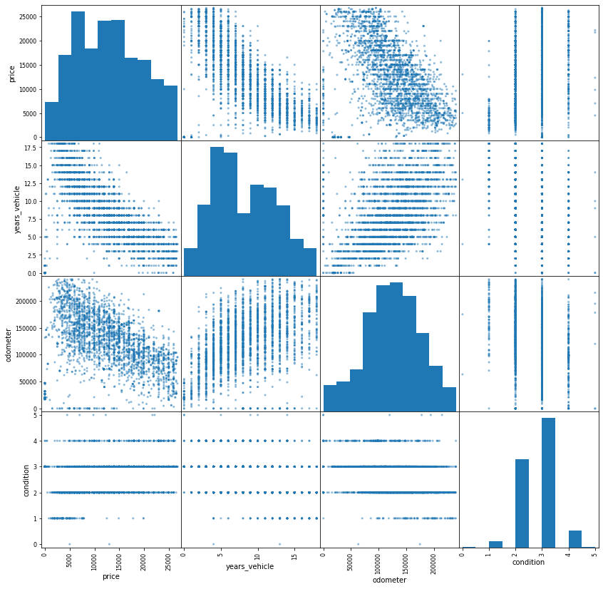

```python
data2_aux=data2.query('(model=="ford f-150") or (model=="chevrolet silverado 1500")')[['price','years_vehicle','odometer','condition']]
display(data2_aux.corr())

pd.plotting.scatter_matrix(data2_aux, figsize=(14, 14))
plt.show()
```

```
automatic    3058
manual         26
other          20
Name: transmission, dtype: int64
```

```
white      809
unknown    546
black      411
red        334
grey       267
silver     266
blue       252
custom      76
green       68
brown       62
yellow       7
purple       3
orange       3
Name: paint_color, dtype: int64
```

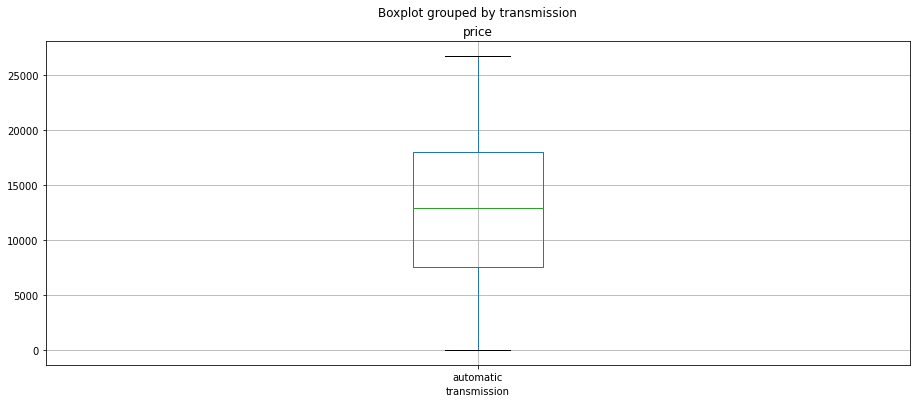

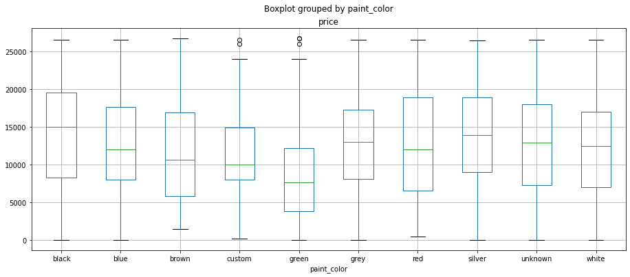

```python
data2_aux=data2.query('(model=="ford f-150") or (model=="chevrolet silverado 1500")')[['price','transmission','paint_color']]

display(data2_aux['transmission'].value_counts())
#Se descarta "manual" y "other" dado que es una muestra muy pequeña (menos de 50 anuncios)
data2_aux.query('transmission=="automatic"').boxplot(column='price',by='transmission',figsize=(15,6))

display(data2_aux['paint_color'].value_counts())
#Se descarta "yellow", "orange" y "purple" dado que es una muestra muy pequeña (menos de 50 anuncios)
data2_aux.query('paint_color not in ["yellow","orange","purple"]').boxplot(column='price',by='paint_color',figsize=(15,6))
```

## Resumen

-`cylinders` era un float, se convirtio a entero  
`is_4wd` era un float, se convirtio a entero  
`date_posted` era un object, fue convertido a datetime.

*En la columna `cylinders` faltaban 5260 filas(10.2% de los datos). Se calculó las medianas de cylinders por modelo y se reemplazó en base a esto*

*En la columna `paint_color` faltaban algunas filas. No se pudo inferir con exactitud de que color eran las filas faltantes, asi que estos datos ausentes fueron remplazados como "unknown"(desconocido).*

*En la columna `is_4wd` los 25572 valores eran 1(es 4x4). No existian 0 ni nigun otro valor, por lo que se dedujo que las filas ausentes correspondian a 0 (no 4x4).Se corrigió.*

*Reemplazamos los valores de condición con valorer numericos (5=nuevo.... 0 = para rescate)*

*Se calcularon rangos tipicos usando la formula (Q2±1.5\*IQR) para las columnas `price`,`years_vehicle` y `odometer` y se creo una nueva tabla despreciado los valores atípicos (valores fuera de los rangos tipicos*

## Conclusión general

*Se buscaron correlaciónes entre los precios de los vehiculos con otras varibles y se dedujo lo siguiente:*

-Existe una fuerte correlación inversa entre el precio del vehiculo y su antiguedad (-0.66).  
Mientras mas antiguo, menor el precio

-Existe una correlación inversa entre el precio del vehiculo y su millaje (-0.45).  
Mientras mas millas, menor el precio

*Además, como era de esperar, aparece una correlación directa entre antiguedad del vehiculo y su millaje(0.5), una correlación inversa ente la antiguedad del vehiculo y su condición(-0.3) y una leve correlación inversa entre millaje y condición (-0,29).*

Mientras mas viejo, mas millas  
Mientras mas viejo, menos condición  
Mientras mas millas, menos condición

*Respecto al analisis de las variables categoricas versus el precio, referente a la transmisión, no se puede concluir nada ya que los tipos de transmisión "manual" y "otros" son muy pocas. Mientras que respecto al color vs precio, se aprecia que el color que registra un valor promedio mas elevado es el `negro`, mientras que el color mas economico parece ser el `verde`.*